# Advanced Data Wrangling

## Why today matters

Days 3-6 assumed your data arrived usable. It rarely does.

Three problems account for most real cleanup:

- **Dates** arrive as text, in inconsistent formats.
- **Text fields** jam several facts into one column.
- **Missing values** hide as `"N/A"`, `"-999"`, or `""`.

Today: `lubridate`, `stringr`, and a disciplined approach to `NA`.

## Dates and times

## Why dates are hard

A date read from a CSV is usually just **characters**:

```r
d <- "2023-03-25"
class(d)
## [1] "character"
```

It looks like a date to you. To R it’s a string, so you can’t

- subtract one date from another,
- sort it into real chronological order,
- or put it on a time axis.

R has proper types for this — `Date` for days, `POSIXct` for date-times.

**`lubridate` turns the text into them.**

## Parsing dates: name the order

`ymd()`, `mdy()`, `dmy()` — the function name tells R the **order** of the parts, not the punctuation. Separators are figured out for you.

```r
ymd("2023-03-25")
## [1] "2023-03-25"
mdy("March 25, 2023")
## [1] "2023-03-25"
dmy("25-Mar-2023")
## [1] "2023-03-25"
mdy("3/25/23")
## [1] "2023-03-25"
```

## Mixed formats in one column

Real columns are not consistent.

`parse_date_time()` takes a **list of possible orders** and tries each in turn:

```r
messy <- c("Jan 15, 2023", "20/02/2023", "2023-03-25", "18-Aug-2022")
parse_date_time(messy, orders = c("mdy", "dmy", "ymd"))
## [1] "2023-01-15 UTC" "2023-02-20 UTC" "2023-03-25 UTC" "2022-08-18 UTC"
```

All four parsed. But the **order you list matters**:

- `"20/02/2023"` is safe — there is no month 20, so only one reading works.
- `"01/02/2023"` is not safe. Both readings work.

Always check the output against the input you started with.

## The ambiguity trap

The same string, parsed twice. Only the order of `orders` changed:

```r
parse_date_time(c("01/02/2023"), orders = c("mdy", "dmy"))
## [1] "2023-01-02 UTC"
parse_date_time(c("01/02/2023"), orders = c("dmy", "mdy"))
## [1] "2023-02-01 UTC"
```

**January 2** or **February 1** — a month apart.

And nothing warns you. No error, no message.

If a column mixes US and European conventions, no function can settle it. You need to know where the data came from.

## Date-times and time zones

```r
t1 <- ymd_hms("2023-03-25 10:30:00")
t2 <- ymd_hms("2023-03-25 14:05:00")
t2 - t1
## Time difference of 3.583333 hours
```

A `difftime` — and **R picks the units**: hours here, days for a month. Use `as.numeric()` before doing arithmetic on it.

Attach a time zone when it matters:

```r
ymd_hms("2023-03-25 10:30:00", tz = "America/Los_Angeles")
## [1] "2023-03-25 10:30:00 PDT"
```

A bare clock time needs `parse_date_time()` and a format code — `I` = 12-hour, `M` = minutes, `p` = AM/PM, `H` = 24-hour:

```r
format(parse_date_time(c("10:30 AM", "2:15 PM"), orders = c("IMp", "HM")), "%H:%M")
## [1] "10:30" "14:15"
```

## Extracting components

Pull pieces out for grouping and plotting — this is how you get “average by month” or “weekday vs. weekend.”

```r
dates <- ymd(c("2023-01-15", "2023-06-30", "2023-11-05"))
tibble(date  = dates,
       year  = year(dates),
       month = month(dates, label = TRUE),
       wday  = wday(dates, label = TRUE))
## # A tibble: 3 × 4
##   date        year month wday
##   <date>     <dbl> <ord> <ord>
## 1 2023-01-15  2023 Jan   Sun
## 2 2023-06-30  2023 Jun   Fri
## 3 2023-11-05  2023 Nov   Sun
```

Without `label = TRUE` you’d get `1` and `6`, not `Jan` and `Jun`. Note the `<ord>` column type: these are *ordered* factors, so they read as names but still sort chronologically rather than alphabetically.

## Strings

## `stringr`: one consistent interface

Every function starts with `str_`, takes the string first, and returns something predictable.

```r
messages <- c("Error: file not found", "Warning: low memory", "error: bad input")
str_detect(messages, regex("error", ignore_case = TRUE))
## [1]  TRUE FALSE  TRUE
str_replace(messages, "Error", "Failure")
## [1] "Failure: file not found" "Warning: low memory"
## [3] "error: bad input"
```

`str_detect()` returns a logical vector — which makes it perfect inside `filter()`.

## Extracting and combining

```r
codes <- c("PROD-1234-A", "PROD-5678-B")
str_sub(codes, 6, 9)                       # by position
## [1] "1234" "5678"
str_c("Dr. ", c("Chen", "Okafor"))         # paste together
## [1] "Dr. Chen"   "Dr. Okafor"
str_c(c("a", "b", "c"), collapse = ", ")   # collapse to one string
## [1] "a, b, c"
```

`str_sub()` by position is brittle — it breaks the moment a code changes length. Prefer a pattern when you can.

## Cleaning text

The unglamorous work that makes joins succeed.

```r
raw <- c("  Cambridge  ", "NEW YORK", "chicago")
str_trim(raw)
## [1] "Cambridge" "NEW YORK"  "chicago"
str_to_title(str_trim(raw))
## [1] "Cambridge" "New York"  "Chicago"
str_replace_all("John.D_New", "[._]", " ")   # _all replaces every match, not just the first
## [1] "John D New"
```

Leading whitespace is invisible and breaks every `==` and `join` you attempt. Trim first, ask questions later.

## Regular expressions

A pattern language for text. A few pieces cover most needs:

| Pattern | Matches |
| --- | --- |
| `\\d` | any digit |
| `\\d+` | one or more digits |
| `[A-Za-z]` | any letter |
| `^` / `$` | start / end of string |
| `.` | any character |
| `\\d{8}` | exactly 8 digits |

```r
str_extract("Order 4521 shipped on line 3", "\\d+")
## [1] "4521"
str_detect("ORD-20230115", "^ORD-\\d{8}$")   # anchored, exactly 8 digits
## [1] TRUE
str_extract("Jane_S_Old", "New|Old")              # vertical bar = either/or
## [1] "Old"
```

## Regex in practice

**The situation:** a column of free-text contact notes, and you need the email address out of each one — or to find the rows that don’t have one.

```r
contacts <- c("ask jane@cmc.edu today", "no address here")
str_extract(contacts, "[\\w.]+@[\\w.]+")
## [1] "jane@cmc.edu" NA
```

- `[\w.]` — **one** character: a letter, digit, `_`, or a literal dot
- `+` — one or more of them
- `@` — itself
- So: *word-or-dot, `@`, word-or-dot*. A space is neither, which is what stops the match at each end of the address.
- In R you type `\\w`; the regex engine receives `\w`.

No match returns `NA` — exactly what you want inside a pipeline.

Regex is far too deep for one class — this covers most everyday cleaning. For the rest: R4DS Ch 14, and https://regex101.com, which explains a pattern piece by piece as you build it.

## Missing values

## `NA` is not the only missing value

The dangerous missing values are the ones R doesn’t recognize.

```r
survey <- tibble(
  id     = 1:8,
  role   = c("senior","senior","senior","senior","junior","junior","junior","junior"),
  income = c(NA, -999999, NA, 145000, 52000, 48000, 51000, -999999),
  status = c("employed","N/A","employed","employed","","employed","employed","N/A"))
summary(survey$income)
##    Min. 1st Qu.  Median    Mean 3rd Qu.    Max.    NA's
## -999999 -737999   49500 -284000   51750  145000       2
```

`-999999` is a sentinel value standing in for “no answer”. R averaged it in and reported a mean income of **-$284,000** — impossible, and nothing warned you.

## `na_if()`: convert disguised missings

`na_if(x, value)` swaps one specific value for a real `NA`. Nest it when a column hides more than one kind of blank.

```r
clean <- survey %>%
  mutate(income = na_if(income, -999999),
         status = na_if(na_if(status, "N/A"), ""))

mean(clean$income, na.rm = TRUE)
## [1] 74000
```

**-$284,000 becomes $74,000.** Same data, same `mean()` call — the only difference is that R now knows which values were never answers.

- **`"N/A"` is not `NA`** — it is ordinary text, so nothing treats it as missing. Same for `""`, `"none"`, `"-"`. Leave it and:
  - `is.na()` counts **zero** missing
  - `count()` reports it as a real category
  - `drop_na()` keeps the row
  - two `"N/A"` rows will **join to each other**
- Look for sentinels *before* computing anything: `-999`, `-999999`, `9999`, `0`.

## Seeing the missingness

`naniar::vis_miss()` maps the whole data frame — a fast way to see how much is gone and where.

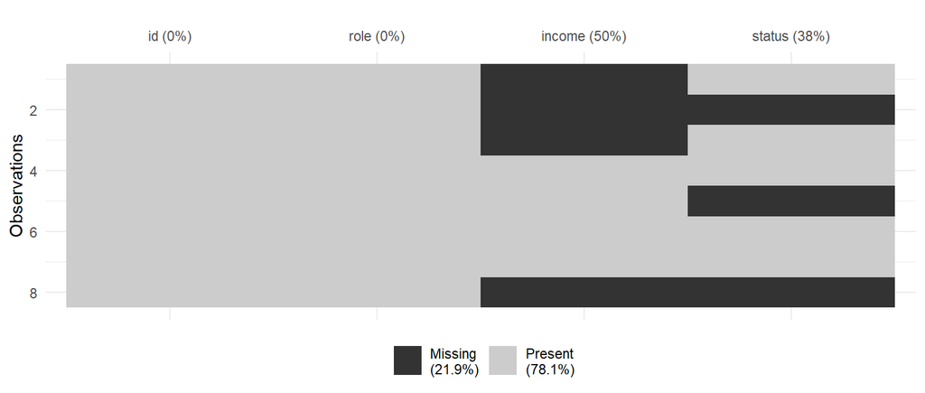

```r
vis_miss(clean) +
  theme(axis.text.x = element_text(angle = 0, hjust = 0.5))  # else labels clip
```

## Is it missing at random?

Counting the gaps tells you *how many*. It does not tell you *who*.

```r
clean %>% group_by(income_missing = is.na(income)) %>%
  summarise(n = n(), pct_senior = 100 * mean(role == "senior"))
## # A tibble: 2 × 3
##   income_missing     n pct_senior
##   <lgl>          <int>      <dbl>
## 1 FALSE              4         25
## 2 TRUE               4         75
```

**75% senior among the missing, 25% among the rest.** Different people — so dropping them pulls the average income down.

Compare the two groups on whatever else you observe. `na.omit()` is a **decision**, not a cleanup step.

## Three options, all defensible

- **Drop** — fine when few and missing at random. Say how many.
- **Impute** — keeps sample size, understates uncertainty.
- **Keep `NA`** with `na.rm = TRUE` — honest, but each column uses a different sample.

No default answer. The indefensible move is doing one of these **silently**.

## Summary

- **`lubridate`:** `ymd()`/`mdy()`/`dmy()`, `parse_date_time()` for mixed formats. Always check what it gave you back.
- **`stringr`:** `str_detect()`, `str_extract()`, `str_replace()`, `str_trim()`.
- **Missing values:** `na_if()` to unmask them, `vis_miss()` to see them, and say what you did.

## For rest of class

- Work on the `day7_activity` — a deliberately messy sales dataset
- Ask me questions if you run into issues